# Determining the Utility of TMPRSS2-ERG Fusion Status for Prediction of Disease Aggressiveness

## Linear Model 5

```r
## Complex LINEAR REGRESSION MODEL + INTERACTION BTWEN TMPRSS and AGE and Capra Score
PrefOLS_NoTMPRSS2 <- lm(Aggressiveness_Score ~ Age + Mutation.Count + Capra.Score, Clinical_Train)
summary(PrefOLS_NoTMPRSS2)
```

```
Call:
lm(formula = Aggressiveness_Score ~ Age + Mutation.Count + Capra.Score,
    data = Clinical_Train)

Residuals:
     Min       1Q   Median       3Q      Max
-1.99247 -0.48058 -0.03034  0.44895  1.99512

Coefficients:
                Estimate Std. Error t value Pr(>|t|)
(Intercept)    -3.390907   0.723142  -4.689 1.04e-05 ***
Age             0.015536   0.012380   1.255    0.213
Mutation.Count  0.071143   0.006995  10.171 2.33e-16 ***
Capra.Score     0.030585   0.046171   0.662    0.509
---
Signif. codes:  0 '***' 0.001 '**' 0.01 '*' 0.05 '.' 0.1 ' ' 1

Residual standard error: 0.7706 on 85 degrees of freedom
Multiple R-squared:  0.6253,    Adjusted R-squared:  0.612
F-statistic: 47.28 on 3 and 85 DF,  p-value: < 2.2e-16
```

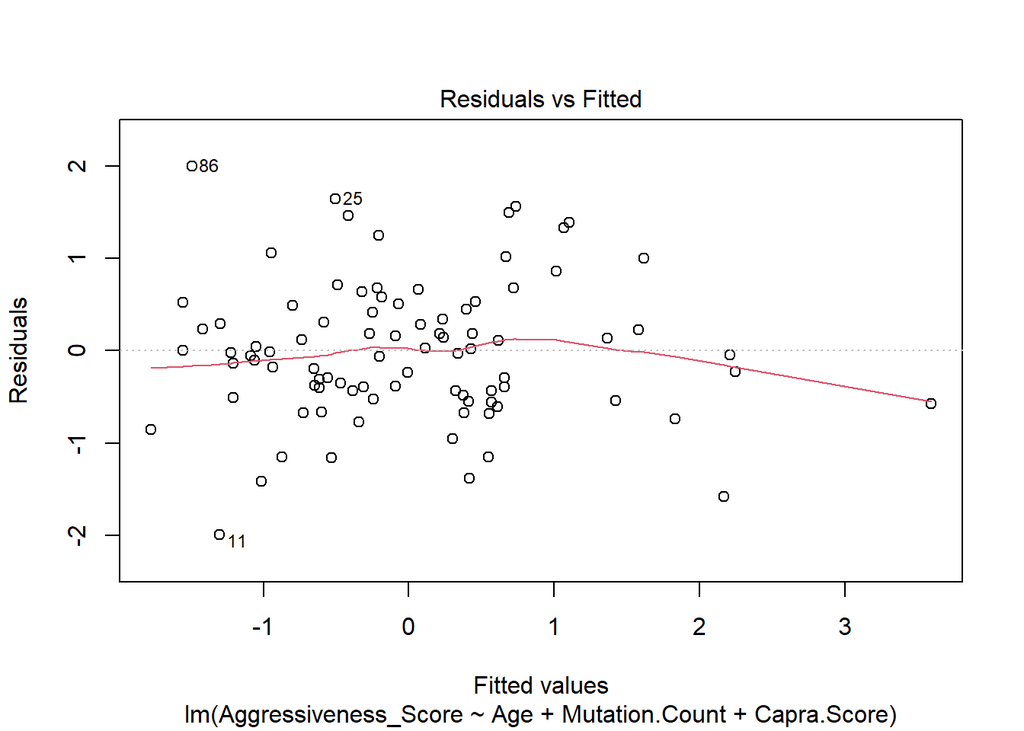

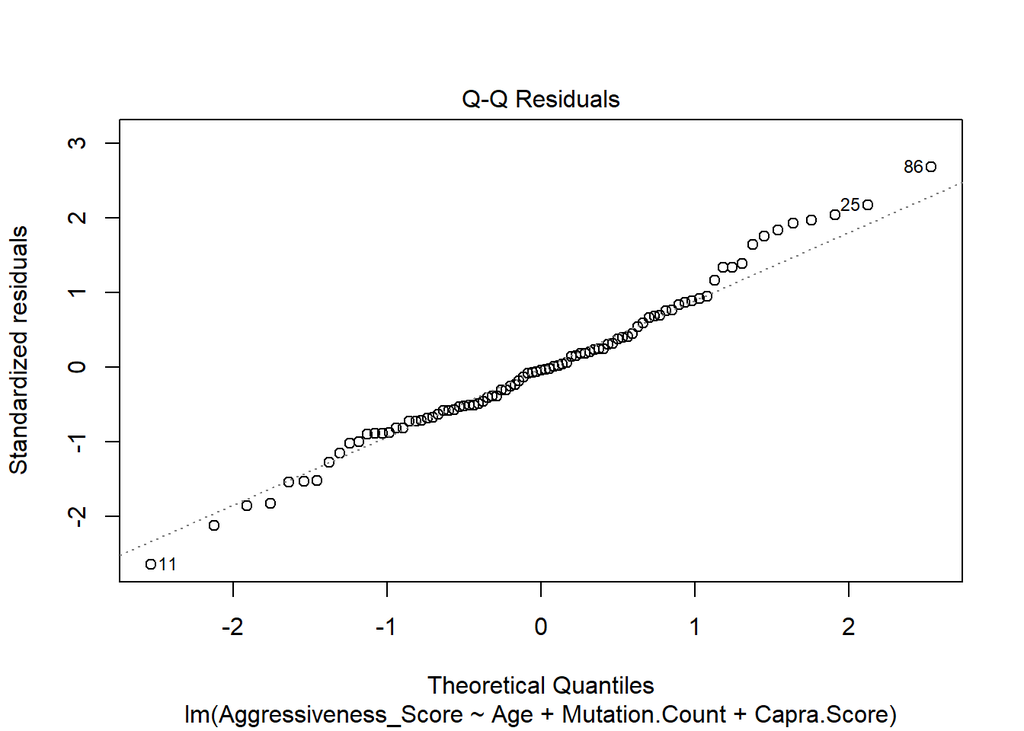

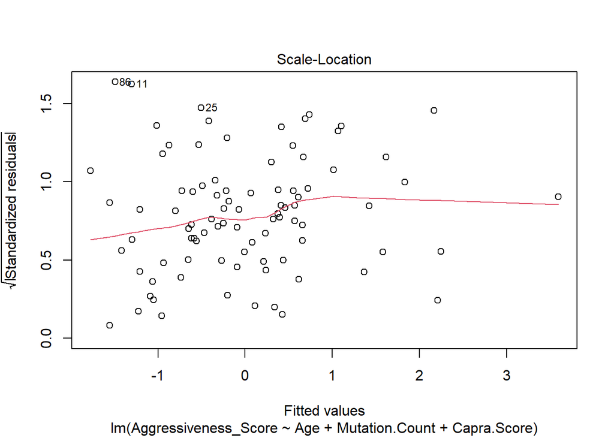

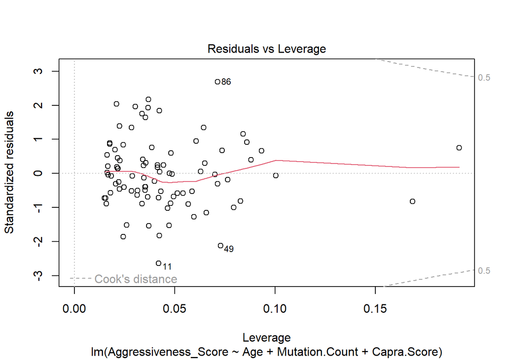

```r
plot(PrefOLS_NoTMPRSS2)
```

## **Lasso Regression**

- Linear Regression models indicate that not all predictors are relevant.
  - Lasso shrinks some coefficients to zero, effectively removing irrelevant predictors.
  - Creates simpler, more interpretable models by focusing only on the most important predictors.
- Introducing LASSO to remove non-relevant predictors and overcome any over fitting concerns

```r
## LASSO REGRESSION MODEL
x <- model.matrix(~ TMPRSS2.Simplified + Interstitial.Deletion +
                                  Age + Mutation.Count + PSA.Status +
                                  Capra.Score + Tumor.Stage.Binary,
               data = Clinical_Train)[,-1] |>
  scale() |> as.matrix()
y <- Clinical_Train$Aggressiveness_Score

## Fit Lasso with cross-validation
lasso_model <- cv.glmnet(x, y, alpha = 1)
print(lasso_model)
```

```
Call:  cv.glmnet(x = x, y = y, alpha = 1)

Measure: Mean-Squared Error

    Lambda Index Measure     SE Nonzero
min 0.0592    31  0.6327 0.1108       4
1se 0.3466    12  0.7381 0.1324       1
```

```r
## Get coefficients at optimal lambda
best_lambda <- lasso_model$lambda.min
lasso_coefficients <- coef(lasso_model, s = best_lambda)
print(lasso_coefficients)
```

```
8 x 1 sparse Matrix of class "dgCMatrix"
                                      s1
(Intercept)                -2.846417e-17
TMPRSS2.SimplifiedPositive -1.334872e-01
Interstitial.DeletionYes    .
Age                         5.811829e-02
Mutation.Count              9.038493e-01
PSA.Status                  .
Capra.Score                 2.000687e-02
Tumor.Stage.BinarypT3       .
```

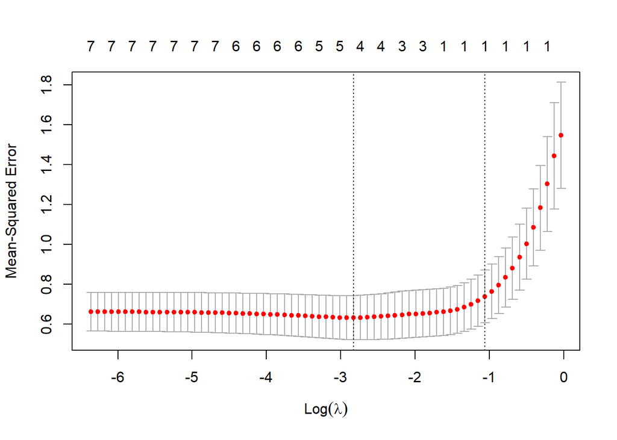

```r
lasso_preferred_predictors = c('TMPRSS2.Full',
                               'Age',
                               'Mutation.Count',
                               'Capra.Score')

## Plot cross-validation results
plot(lasso_model)
```

## **Random Forest 1**

- Uses TMRPSS2-ERG fusion status (binary variable) and Age (continuous variable) to predict aggressiveness of disease

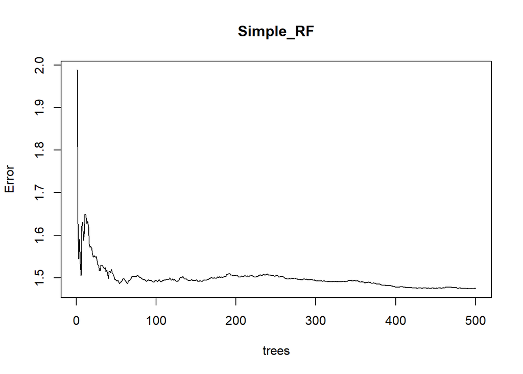

```r
## Simple Random Forest Model
set.seed(12509)

Simple_RF <- randomForest(Aggressiveness_Score ~ TMPRSS2.Simplified + Age, data = Clinical_Train)
plot(Simple_RF)
```

```r
importance(Simple_RF)
```

```
                   IncNodePurity
TMPRSS2.Simplified      3.708441
Age                    32.914710
```

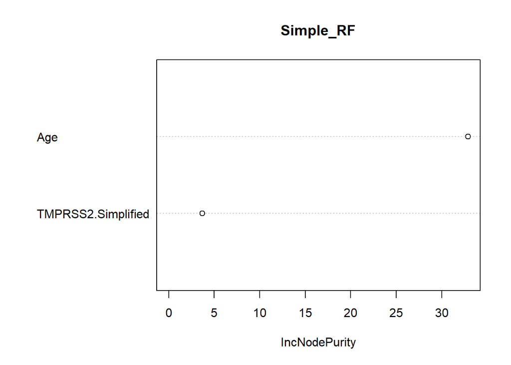

```r
varImpPlot(Simple_RF)
```

## **Random Forest 2**

```r
## Complex Random Forest Model
set.seed(12509)

Complex_RF <- randomForest(Aggressiveness_Score ~ TMPRSS2.Simplified + Age + Mutation.Count, data = Clinical_Train)
print(Complex_RF)
```

```
Call:
 randomForest(formula = Aggressiveness_Score ~ TMPRSS2.Simplified +      Age + Mutation.Count, data = Clinical_Train)
               Type of random forest: regression
                     Number of trees: 500
No. of variables tried at each split: 1

          Mean of squared residuals: 0.7123463
                    % Var explained: 52.94
```

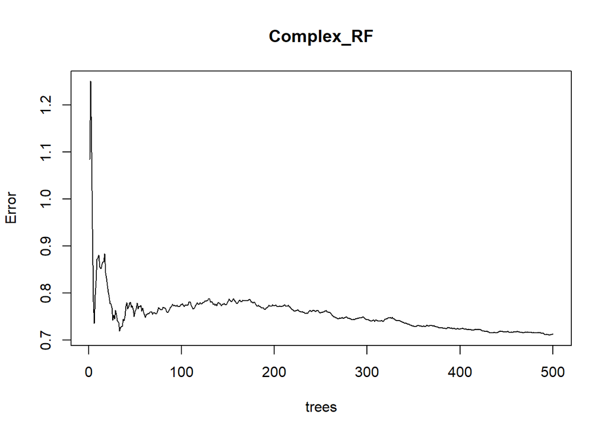

```r
plot(Complex_RF)
```

```r
importance(Complex_RF)
```

```
                   IncNodePurity
TMPRSS2.Simplified      2.787681
Age                    22.815690
Mutation.Count         61.005600
```

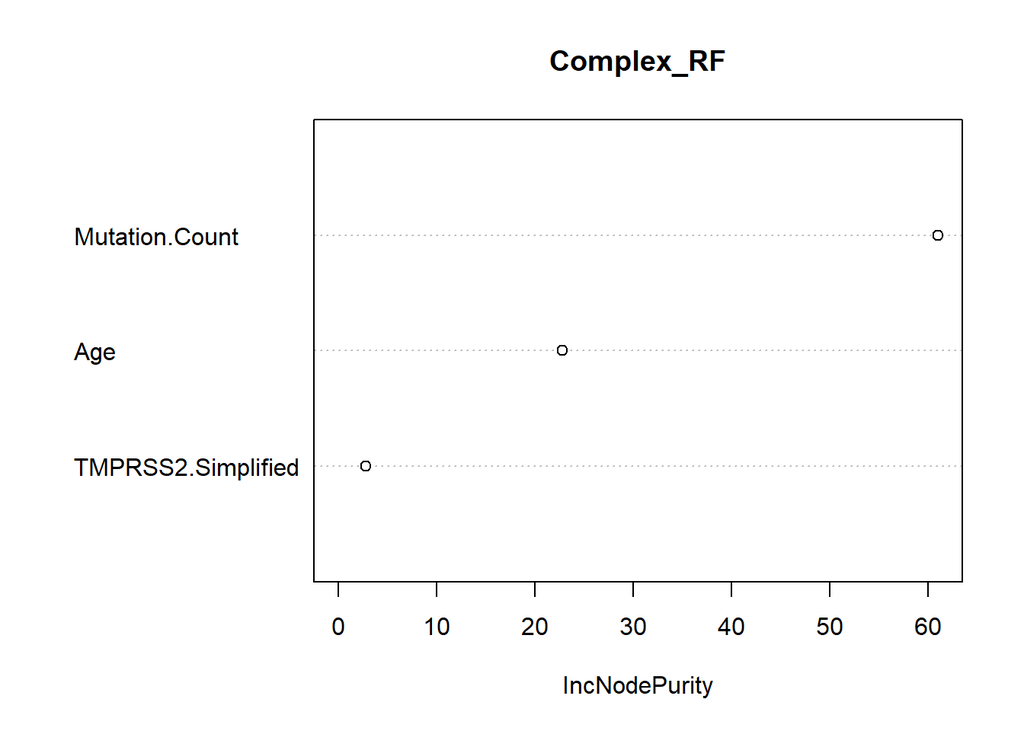

```r
varImpPlot(Complex_RF)
```

## **Random Forest 3**

- Complex Random Forest + Lasso: this is a Random Forest regression model, built using a set of predictors identified as being preferred through lasso

```r
## Complex Random Forest Model + Lasso Preferred Predictors
set.seed(12509)

lasso_preferred_rf <- randomForest(Aggressiveness_Score ~ ., data = Clinical_Train[,c('Aggressiveness_Score', lasso_preferred_predictors)])
print(lasso_preferred_rf)
```

```
Call:
 randomForest(formula = Aggressiveness_Score ~ ., data = Clinical_Train[,      c("Aggressiveness_Score", lasso_preferred_predictors)])
               Type of random forest: regression
                     Number of trees: 500
No. of variables tried at each split: 1

          Mean of squared residuals: 0.7431176
                    % Var explained: 50.9
```

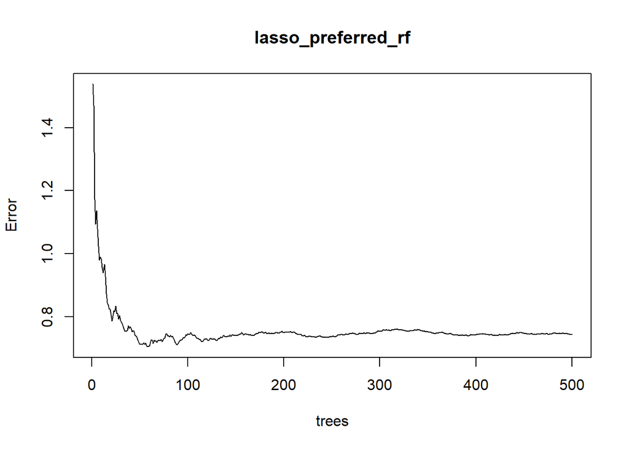

```r
plot(lasso_preferred_rf)
```

```r
importance(lasso_preferred_rf)
```

```
               IncNodePurity
TMPRSS2.Full        5.607063
Age                22.368772
Mutation.Count     58.338648
Capra.Score        14.617159
```

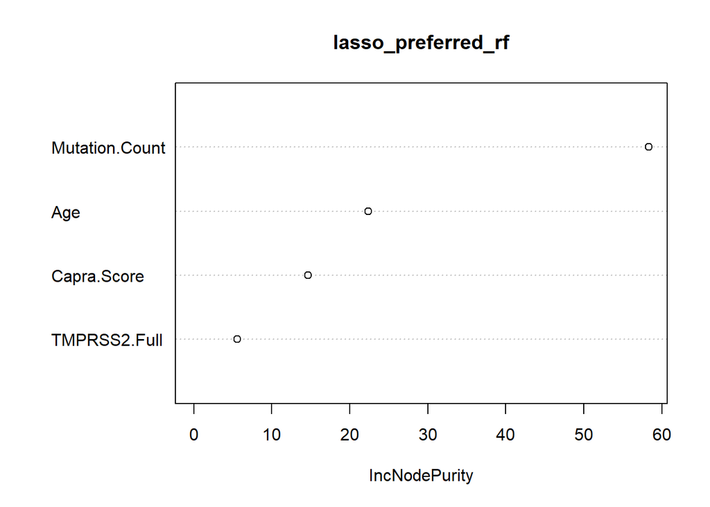

```r
varImpPlot(lasso_preferred_rf)
```

## Linear Regression Model Using Lasso Preferred Predictors

- Re-assessed accuracy of Linear Regression Models - took Lasso Preferred Predictors and applied to LR Model

```r
lasso_preferred_lm <- lm(Aggressiveness_Score ~ ., data = Clinical_Train[, c('Aggressiveness_Score', lasso_preferred_predictors)])
summary(lasso_preferred_lm)
```

```
Call:
lm(formula = Aggressiveness_Score ~ ., data = Clinical_Train[,
    c("Aggressiveness_Score", lasso_preferred_predictors)])

Residuals:
     Min       1Q   Median       3Q      Max
-2.14599 -0.51798 -0.07578  0.49159  1.80745

Coefficients:
                                                 Estimate Std. Error t value
(Intercept)                                     -3.152040   0.711455  -4.430
TMPRSS2.FullPositive, no interstitial deletion  -0.606157   0.211471  -2.866
TMPRSS2.FullPositive with interstitial deletion -0.262272   0.182761  -1.435
Age                                              0.013331   0.012039   1.107
Mutation.Count                                   0.074555   0.006853  10.880
Capra.Score                                      0.028424   0.044544   0.638
                                                Pr(>|t|)
(Intercept)                                     2.85e-05 ***
TMPRSS2.FullPositive, no interstitial deletion   0.00526 **
TMPRSS2.FullPositive with interstitial deletion  0.15503
Age                                              0.27135
Mutation.Count                                   < 2e-16 ***
Capra.Score                                      0.52516
---
Signif. codes:  0 '***' 0.001 '**' 0.01 '*' 0.05 '.' 0.1 ' ' 1

Residual standard error: 0.7431 on 83 degrees of freedom
Multiple R-squared:  0.6598,    Adjusted R-squared:  0.6393
F-statistic: 32.19 on 5 and 83 DF,  p-value: < 2.2e-16
```

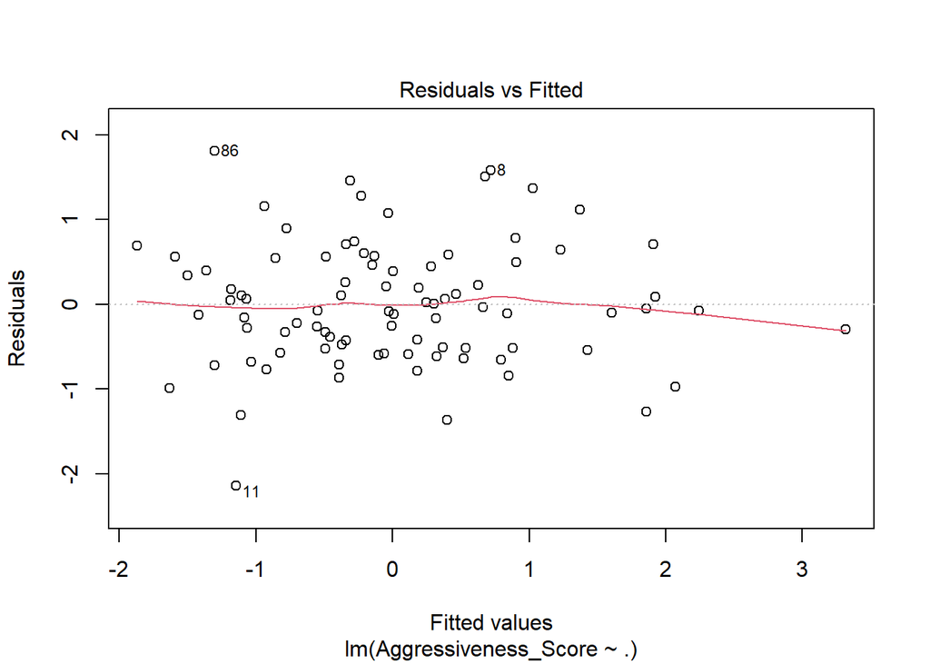

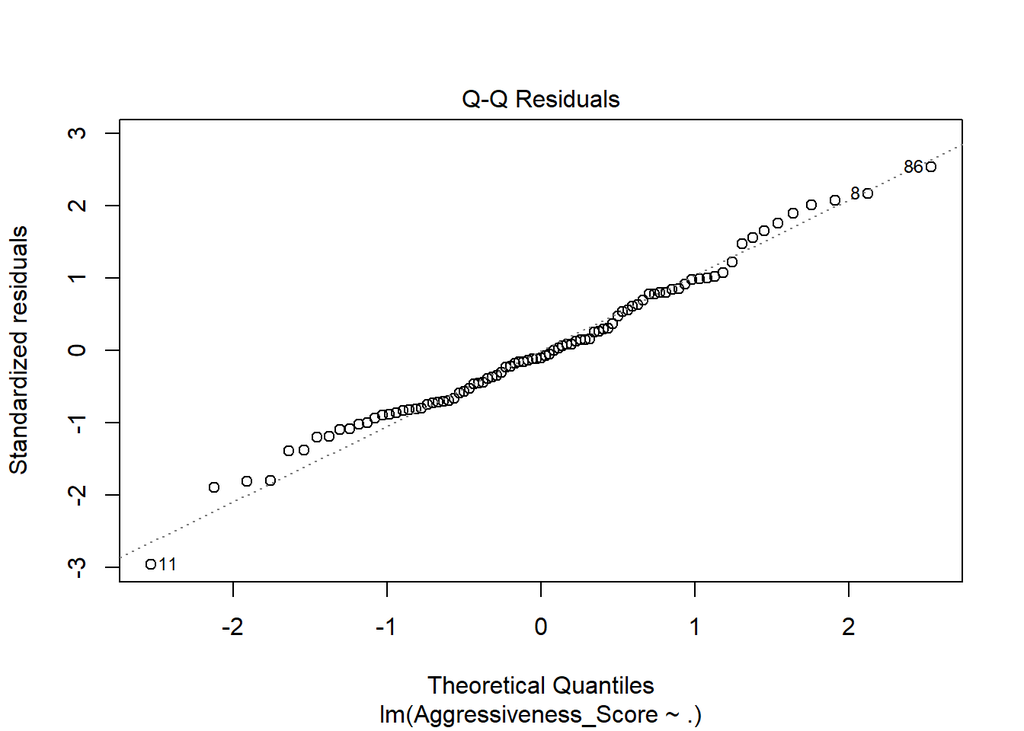

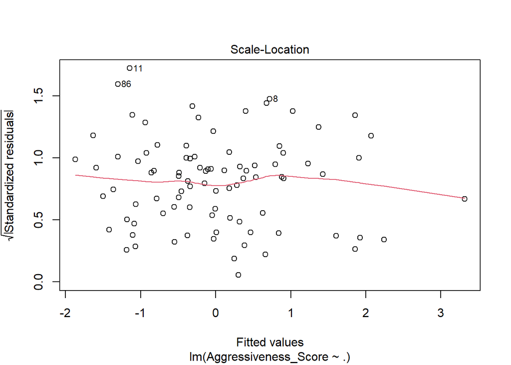

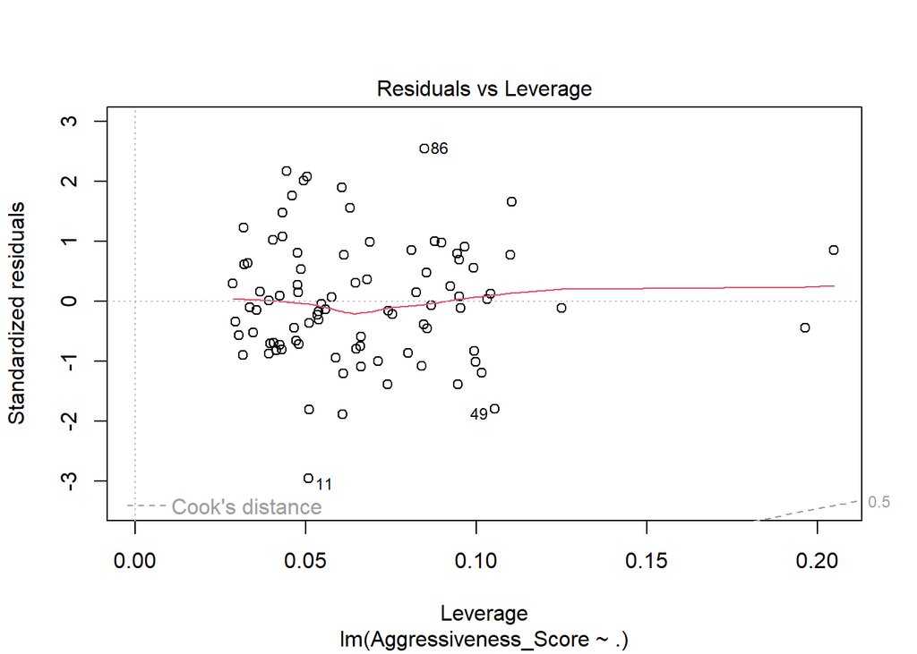

```r
plot(lasso_preferred_lm)
```

## Generate Predictions for Models

- Compute prediction performance for each of the data frames mentioned above
  - Useful metrics are RMSE, MAE, and RSq
  - Performing on training and testing data (separate data frames)

```r
## Generate training predictions
Train_Predictions = Clinical_Train |>
  select(Aggressiveness_Score) |>
  mutate(LASSO_Pref_LM_No_TMPRSS2 = predict(PrefOLS_NoTMPRSS2, newdata = Clinical_Train),
         LASSO_Pref_LM_With_TMPRSS2 = predict(lasso_preferred_lm, newdata = Clinical_Train),
         Simple_Random_Forest = predict(Simple_RF, newdata = Clinical_Train),
         Full_Random_Forest = predict(Complex_RF, newdata = Clinical_Train),
         LASSO_Pref_Random_Forest = predict(lasso_preferred_rf, newdata = Clinical_Train))

## Generate training metrics
Train_Metrics = Train_Predictions |>
  pivot_longer(-Aggressiveness_Score, names_to='Model', values_to='Prediction') |>
  group_by(Model) |>
  summarize(Train_RMSE = sqrt(mean((Aggressiveness_Score-Prediction)^2)),
            Train_MAE = mean(abs(Aggressiveness_Score-Prediction)),
            Train_RSq = cor(Aggressiveness_Score, Prediction)^2) |>
  arrange(Train_RMSE)

## Generate testing predictions
Test_Predictions = Clinical_Test |>
  select(Aggressiveness_Score) |>
  mutate(LASSO_Pref_LM_No_TMPRSS2 = predict(PrefOLS_NoTMPRSS2, newdata = Clinical_Test),
         LASSO_Pref_LM_With_TMPRSS2 = predict(lasso_preferred_lm, newdata = Clinical_Test),
         Simple_Random_Forest = predict(Simple_RF, newdata = Clinical_Test),
         Full_Random_Forest = predict(Complex_RF, newdata = Clinical_Test),
         LASSO_Pref_Random_Forest = predict(lasso_preferred_rf, newdata = Clinical_Test))

## Generate testing metrics
Test_Metrics = Test_Predictions |>
  pivot_longer(-Aggressiveness_Score, names_to='Model', values_to='Prediction') |>
  group_by(Model) |>
  summarize(Test_RMSE = sqrt(mean((Aggressiveness_Score-Prediction)^2)),
            Test_MAE = mean(abs(Aggressiveness_Score-Prediction)),
            Test_RSq = cor(Aggressiveness_Score, Prediction)^2) |>
  arrange(Test_RMSE)
```

```r
## Combine train and test metrics
(Combined_Metrics = full_join(Train_Metrics, Test_Metrics, by='Model'))
```

```
# A tibble: 5 × 7
  Model               Train_RMSE Train_MAE Train_RSq Test_RMSE Test_MAE Test_RSq
  <chr>                    <dbl>     <dbl>     <dbl>     <dbl>    <dbl>    <dbl>
1 LASSO_Pref_Random_…      0.543     0.439     0.892     0.791    0.652  0.405
2 Full_Random_Forest       0.618     0.505     0.854     0.782    0.637  0.430
3 LASSO_Pref_LM_With…      0.718     0.564     0.660     0.674    0.553  0.561
4 LASSO_Pref_LM_No_T…      0.753     0.582     0.625     0.626    0.465  0.588
5 Simple_Random_Fore…      1.05      0.823     0.372     1.03     0.821  0.00935
```

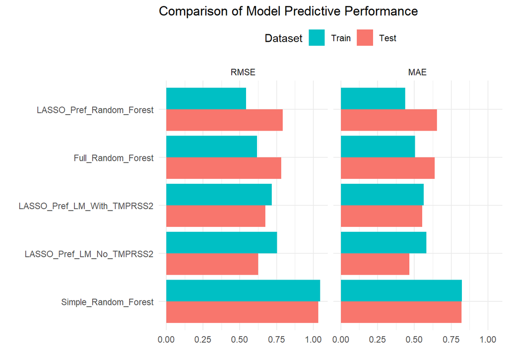

```r
## Make column plot of model performance
Combined_Metrics |>
  pivot_longer(-Model, names_to = 'Metric', values_to = 'Value') |>
  separate(Metric, c('Dataset', 'Metric'), sep='_') |>
  filter(Metric != 'RSq') |>
  mutate(Metric = factor(Metric, levels=c('RMSE', 'MAE')),
         Dataset = factor(Dataset, levels=c('Train', 'Test'))) |>
  group_by(Dataset, Metric) |>
  arrange(Value) |>
  mutate(Model = fct_inorder(Model)) |>
  ggplot(aes(y=fct_rev(Model), x=Value, fill=fct_rev(Dataset))) +
  facet_wrap(~Metric) +
  geom_col(position='dodge') +
  labs(title = 'Comparison of Model Predictive Performance',
       y ='', x ='', fill = 'Dataset') +
  scale_fill_discrete(breaks = c('Train', 'Test')) +
  theme_minimal() +
  theme(legend.position = 'top')
```

# Conclusion

### Summary

**Limitations**

Despite being deemed sufficient for the purposes of this project, the sample size included in our analysis (n = 112) is modest. This likely led to a degree of reduced statistical power, increased bias risk, and lower generalizability. Furthermore, the dataset was curated in 2012. The key metrics still hold utility for prostate cancer screening, diagnosis, and prognosis, however we now likely have a more nuanced understanding of the disease (from 12 years ago) and there might be more impactful variables that we could have used to generate the compositive score and/or include in our analysis. Finally, I believe that greater longitudinal visibility into the patient journey might have unlocked new insights regarding treatment decision, impact of therapeutic pressure, and ultimately how this linked back to aggressiveness of disease. The current sample appears somewhat heterogeneous in terms of disease state and decision to evaluate post-prostatectomy.

# References

- American Cancer Society. Prostate cancer causes, risk factors, and prevention. Accessed October, 2024. https://www.cancer.org/cancer/types/prostate-cancer/causes-risks-prevention.html
- Broad Institute. Prostate adenocarcinoma (Broad, 2013). cBioPortal. Accessed October, 2024. https://www.cbioportal.org/study/clinicalData?id=prad_broad
- Broad Institute. Prostate adenocarcinoma (Broad, 2013). cBioPortal. Accessed October, 2024. https://www.cbioportal.org/study/summary?id=prad_broad
- Cuzick J, Thorat MA, Andriole G, et al. Prevention and early detection of prostate cancer. Lancet Oncol. 2014;15(11):e484-e492. doi:10.1016/S1470-2045(14)70211-6
- Hamdy FC, Donovan JL, Lane JA, et al. 10-Year outcomes after monitoring, surgery, or radiotherapy for localized prostate cancer. N Engl J Med. 2016;375(15):1415-1424. doi:10.1056/NEJMoa1606221
- Litwin MS, Tan HJ. The diagnosis and treatment of prostate cancer: a review. Nat Rev Dis Primers. 2020;6(1):87. doi:10.1038/s41572-020-00243-0
- Nakabayashi M, Sartor O. Immunotherapy for prostate cancer: recent progress and future prospects. Curr Opin Urol. 2015;25(5):549-556. doi:10.1097/MOU.0000000000000196
- Paller CJ, Antonarakis ES. Management of biochemically recurrent prostate cancer after local therapy: evolving standards of care and new directions. Clin Adv Hematol Oncol. 2019;17(4):220-230.
- Roswell Park Comprehensive Cancer Center. What are the treatment options for aggressive prostate cancer? Accessed November, 2024. https://www.roswellpark.org/cancertalk/202010/what-are-treatment-options-aggressive-prostate-cancer
- Sanda MG, Chen RC, Crispino T, et al. Patient-Reported Outcomes After Monitoring, Surgery, or Radiotherapy for Prostate Cancer. N Engl J Med. 2017;375(15):1415-1424. doi:10.1056/NEJMsr1807462
- Sweeney CJ, Chen YH, Carducci M, et al. Chemohormonal therapy in metastatic hormone-sensitive prostate cancer. N Engl J Med. 2015;373(8):737-746. doi:10.1056/NEJMoa1503747
- Tangen CM, Hussain MH, Higano CS, et al. Improved overall survival with enzalutamide in men with castration-resistant prostate cancer. Lancet Oncol. 2012;13(10):983-992. doi:10.1016/S1470-2045(12)70300-9
- UroToday. ASCO 2019: HSD3B1 and OS in men with low-volume metastatic prostate cancer treated with ADT or chemohormonal therapy in the CHAARTED randomized trial. Accessed November, 2024. https://www.urotoday.com/conference-highlights/asco-2019-annual-meeting/asco-2019-prostate-cancer/113075-asco-2019-hsd3b1-and-os-in-men-with-low-volume-metastatic-prostate-cancer-treated-with-adt-or-chemohormonal-therapy-in-the-chaarted-randomized-trial.html
- Van Hemelrijck M, Garmo H, Holmberg L, et al. Endocrine treatment, serum testosterone levels, and mortality in men with locally advanced and metastatic prostate cancer: a nationwide population-based study. J Clin Oncol. 2015;33(3):266-275. doi:10.1200/JCO.2014.56.1415
- Vlachostergios PJ, Puca L, Beltran H. Emerging Variants of Neuroendocrine Prostate Cancer: Therapeutic Implications. Curr Oncol Rep. 2020;22(8):74. doi:10.1007/s11912-020-00943-5